# Florence_analysis

Dario Fabiani

7/1/2021

# Introduction

For the analysis I am going to use the GeoPackage I made and download it from the Python script. The Analysis is focused on trying to understand if the variable price is spatial auto-correlated. Then, i am also going to put the ‘Price’ variable in a model and see if it may be related to some other variables and if i need to use a spatial regression analysis.

The Variables of the dataset are : **rione**, **neighborhood**, **prop_pop**, **price**, **poi_type_turism**, **poi_type**, **es_vicinato**, **es_mddimensioni**, **es_grdimensioni**. I am going to later explained each of them.

The analysis is made on the “districts” (the Rioni) of each neighborhood. Why this? Well, my question is if there are significant differences in the Rioni itself, that should better account for a spatial dependence.

Firstly, i am going to compute the **Global spatial autocorrelation** then the **Local** one. The first step of the analysis is made calculating 3 different types of Spatial weight matrix: two *knns* and a *contiguity-based*. This was necessary since the analysis itself is mainly based on the Spatial weight matrix, due to the consequences it has on the computations.

Then, i am going to check the **Spatial auto-correlation of the variable Price** and plot it. Hence, to estimate the *optimal* OLS model i use a subset selection. Then I am going to test each of the model with the lm.morantest and also with the permutation bootstrap approach. Eventually, I am going to check for Spatial Local auto-correlation with a Moran scatterplot.

From the analysis it emerges that the variable **price** is **Spatial autocorrelated**, but the model made to predict it, once i apply the Moran’s I test on the OLS residuals, it heavily depends on the Spatial weight matrices, and it does not give any evidence to reject the null hypothesis. The Monte Carlo approach is the best one to actually see that even the only significant observed variable was in the right tail of the distribution, hence not representative. The Local analysis is another proof of the lack of significance of Spatial auto-correlation of the spatial units.

# Setting up the data

I read the file made on the python notebook

```r
flo <- readOGR(dsn ="flo_analysis.gpkg" , layer = "rioni" )
```

We start the analysis calculating the centroids

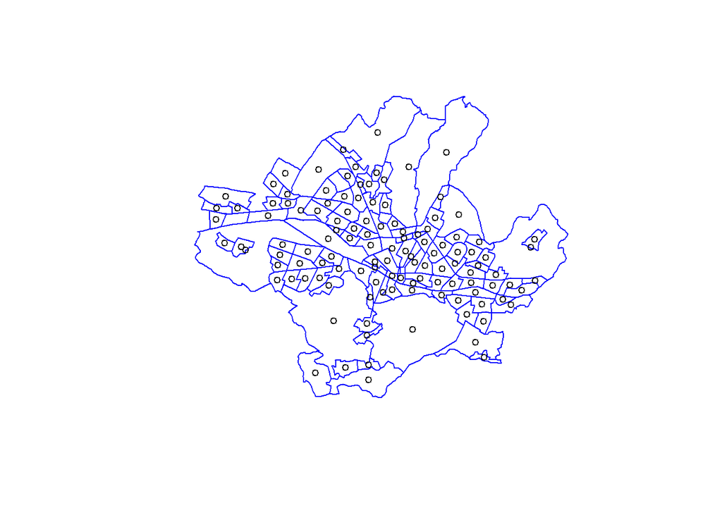

```r
coords <- coordinates(flo)
plot(flo, border="blue") ;points(coords, cex=0.8)
```

Check for outliers in the variable price

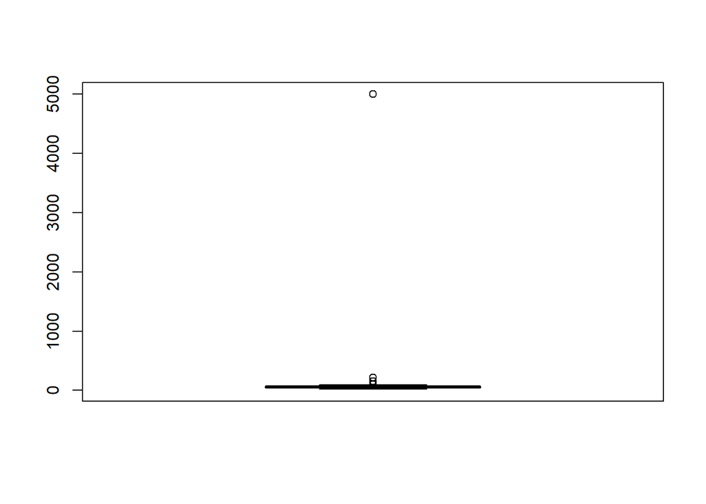

```r
boxplot(flo$price)
```

There is an outlier. I have three choices: set it as the median of that neighbourhood, delete the rione it belongs to or set it as a default value still higher than the rest. I am going to set it with a value of 200, in this way, in the later Moran Scatterplot it will still be above the average as price and it will still be a variable of interest.

```r
subset <- flo[flo$neighbourhood == 'Rifredi',]
head(subset@data)
```

```
##                   rione neighbourhood  prop_pop  price poi_type_turism poi_type
## 1     PIANA DI CASTELLO       Rifredi 0.2885917   36.5               0        1
## 2             AEROPORTO       Rifredi 0.2885917 5000.0               0        0
## 3 ILPALAGIO DEGLI SPINI       Rifredi 0.2885917   23.0               2        0
## 4             OSMANNORO       Rifredi 0.2885917   20.0               2        0
## 5              PETRIOLO       Rifredi 0.2885917   43.0               1        0
## 6              PERETOLA       Rifredi 0.2885917   38.5               0        0
##   es_vicinato es_mddimensioni es_grdimensioni
## 1           8               1               0
## 2           0               0               0
## 3           8               3               0
## 4          19               1               2
## 5          20               4               0
## 6          23               0               0
```

```r
flo$price[which.max(flo$price)] <- 200
```

# Analysis - Price Spatial auto-correlation

Now, I create three different Spatial Weight Matrices. First of all, I need to define the spatial topology, the concept of closeness/neighborhood.

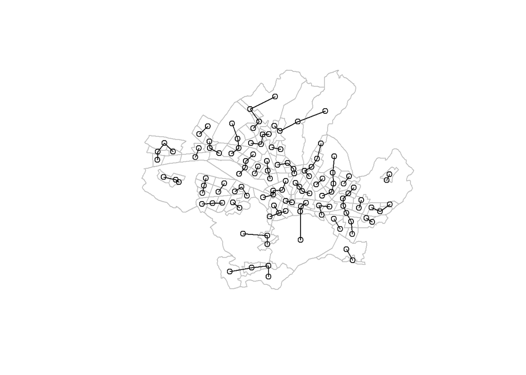

```r
knn1 <- knn2nb(knearneigh(coords,k=1,longlat=T))
plot(flo, border="grey");plot(knn1, coords, add=TRUE)
```

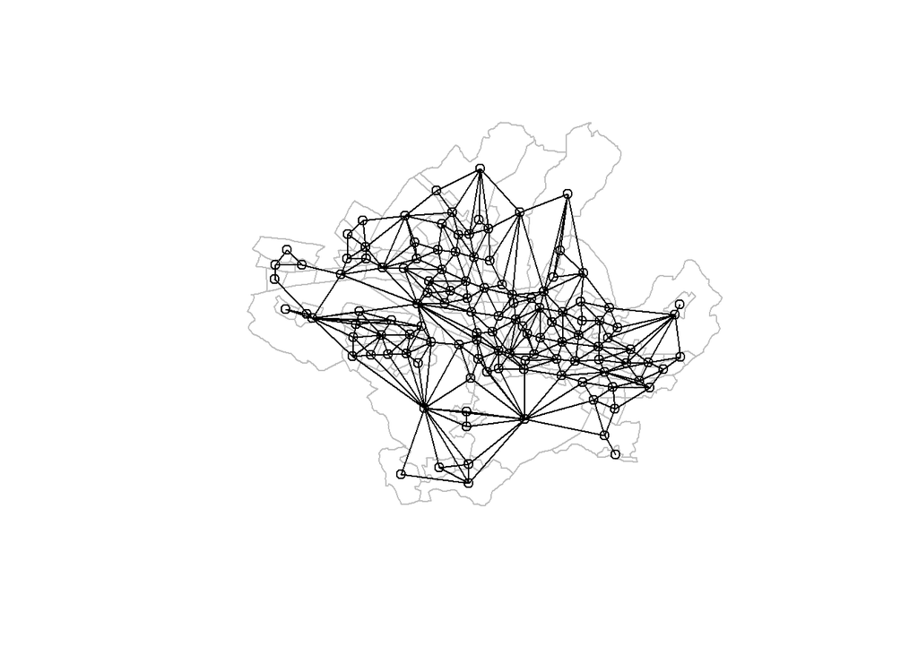

```r
contnb <- poly2nb(flo, queen=T) #queen = T means "Common border and corner points of the spatial unit"
plot(flo, border="grey");plot(contnb, coords, add=TRUE)
```

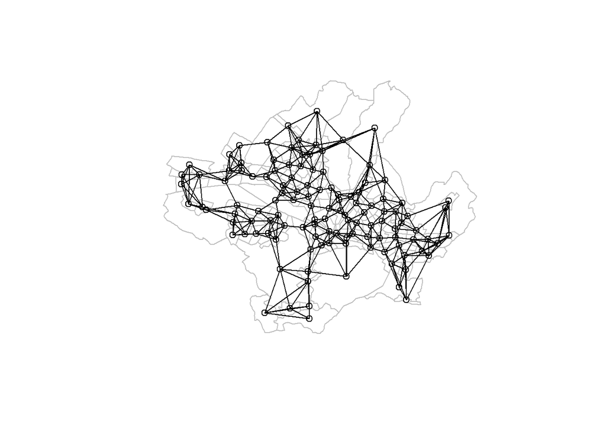

```r
knn2 <- knn2nb(knearneigh(coords,k=5,longlat=T))
plot(flo, border="grey");plot(knn2, coords, add=TRUE)
```

Now, i can build the spatial weight matrix row-standardized

```r
sp_w1 <- nb2listw(knn1,style = 'W')
sp_w2 <- nb2listw(knn2,style = 'W')
sp_w3 <- nb2listw(contnb,style = 'W')
```

I apply the Moran’s I test to the variable of interest, **Price**, to assess if the Null Hypothesis of *No spatial autocorrelation can be rejected*. Before doing that, I can plot the quantile distribution which may suggest the presence of Spatial autocorrelation.

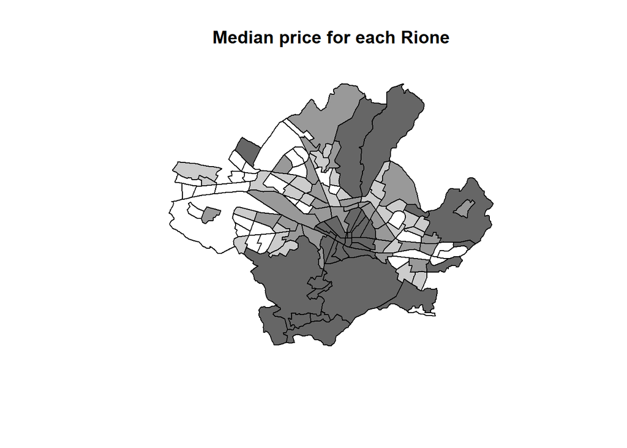

```r
brks <- round(quantile(flo$price), digits=3)
colours <- grey((length(brks):2)/length(brks))
plot(flo, col=colours[findInterval(flo$price, brks, all.inside=TRUE)]);title(main="Median price for each Rione")
```

Then, I test the variable price to see if it is spatially auto-correlated. I am going to do that with each of the Spatial weight matrices I computed. I am testing them under the assumption of normality, randomization and with the Monte Carlo test.

```r
moran.test(flo$price, sp_w1, randomisation=F) #p-value high
```

```
##
##  Moran I test under normality
##
## data:  flo$price
## weights: sp_w1
##
## Moran I statistic standard deviate = 0.47738, p-value = 0.3165
## alternative hypothesis: greater
## sample estimates:
## Moran I statistic       Expectation          Variance
##       0.046681933      -0.008333333       0.013281276
```

```r
moran.test(flo$price, sp_w1, randomisation=T) #p-value high
```

```
##
##  Moran I test under randomisation
##
## data:  flo$price
## weights: sp_w1
##
## Moran I statistic standard deviate = 0.51392, p-value = 0.3037
## alternative hypothesis: greater
## sample estimates:
## Moran I statistic       Expectation          Variance
##       0.046681933      -0.008333333       0.011459581
```

```r
moran.mc(flo$price, sp_w1, nsim=999) #p-value high
```

```
##
##  Monte-Carlo simulation of Moran I
##
## data:  flo$price
## weights: sp_w1
## number of simulations + 1: 1000
##
## statistic = 0.046682, observed rank = 763, p-value = 0.237
## alternative hypothesis: greater
```

```r
moran.test(flo$price, sp_w2, randomisation=F) #p-value low
```

```
##
##  Moran I test under normality
##
## data:  flo$price
## weights: sp_w2
##
## Moran I statistic standard deviate = 3.284, p-value = 0.0005116
## alternative hypothesis: greater
## sample estimates:
## Moran I statistic       Expectation          Variance
##       0.165364949      -0.008333333       0.002797511
```

```r
moran.test(flo$price, sp_w2, randomisation=T) #p-value low
```

```
##
##  Moran I test under randomisation
##
## data:  flo$price
## weights: sp_w2
##
## Moran I statistic standard deviate = 3.5355, p-value = 0.0002035
## alternative hypothesis: greater
## sample estimates:
## Moran I statistic       Expectation          Variance
##       0.165364949      -0.008333333       0.002413729
```

```r
moran.mc(flo$price, sp_w2, nsim=999) #p-value low
```

```
##
##  Monte-Carlo simulation of Moran I
##
## data:  flo$price
## weights: sp_w2
## number of simulations + 1: 1000
##
## statistic = 0.16536, observed rank = 995, p-value = 0.005
## alternative hypothesis: greater
```

```r
moran.test(flo$price, sp_w3, randomisation=F) #p-value low
```

```
##
##  Moran I test under normality
##
## data:  flo$price
## weights: sp_w3
##
## Moran I statistic standard deviate = 2.3601, p-value = 0.009135
## alternative hypothesis: greater
## sample estimates:
## Moran I statistic       Expectation          Variance
##       0.123536590      -0.008333333       0.003122009
```

```r
moran.test(flo$price, sp_w3, randomisation=T) #p-value low
```

```
##
##  Moran I test under randomisation
##
## data:  flo$price
## weights: sp_w3
##
## Moran I statistic standard deviate = 2.5402, p-value = 0.005539
## alternative hypothesis: greater
## sample estimates:
## Moran I statistic       Expectation          Variance
##       0.123536590      -0.008333333       0.002694952
```

```r
moran.mc(flo$price, sp_w3, nsim=999) #p-value low
```

```
##
##  Monte-Carlo simulation of Moran I
##
## data:  flo$price
## weights: sp_w3
## number of simulations + 1: 1000
##
## statistic = 0.12354, observed rank = 987, p-value = 0.013
## alternative hypothesis: greater
```

The best results are given by the second Spatial weigh matrix, the one with a knn of 5. # Analysis- Global Spatial autocorrelation

Next step is to apply the Moran’s I test in OLS residuals. But before doing that i am going to apply a best subset Selection on these variables: prop_pop = proportion of population in each *Neighborhood* (not for each Rione) poi_type_turism = amount of Touristic Point of Interests in each Rione es_vicinato = Esercizi commerciali di vicinato es_meddimensioni = Esercizi Commerciali di media dimensioni es_grdimensioni = Esercizi Commerciali di grandi dimensioni

```r
library(leaps)
regfit.full = regsubsets(price ~ prop_pop + poi_type_turism +
                    es_vicinato + es_mddimensioni + es_grdimensioni,flo)
summary(regfit.full)
```

```
## Subset selection object
## Call: regsubsets.formula(price ~ prop_pop + poi_type_turism + es_vicinato +
##     es_mddimensioni + es_grdimensioni, flo)
## 5 Variables  (and intercept)
##                 Forced in Forced out
## prop_pop            FALSE      FALSE
## poi_type_turism     FALSE      FALSE
## es_vicinato         FALSE      FALSE
## es_mddimensioni     FALSE      FALSE
## es_grdimensioni     FALSE      FALSE
## 1 subsets of each size up to 5
## Selection Algorithm: exhaustive
##          prop_pop poi_type_turism es_vicinato es_mddimensioni es_grdimensioni
## 1  ( 1 ) "*"      " "             " "         " "             " "
## 2  ( 1 ) " "      "*"             " "         "*"             " "
## 3  ( 1 ) "*"      "*"             " "         "*"             " "
## 4  ( 1 ) "*"      "*"             "*"         "*"             " "
## 5  ( 1 ) "*"      "*"             "*"         "*"             "*"
```

The Best subset selection finds that the best one-variable contains only ‘prop_pop’, while the best two-variable model contains ‘poi_type_turism’ and ‘es_mddimensioni’ and lastly the third model see a combination of the previous ones. Hence i am going to test each of these three models.

Now, i can use the Moran’s I test of spatial auto-correlation in each of the OLS residuals. I use the Moran’s I test since it is a diagnostic tool to detect the presence of spatial auto-correlation in the residuals of a linear regression model.

```r
lm_price_1 <- lm(price ~ prop_pop , flo)
lm_price_2 <- lm(price ~  poi_type_turism + es_mddimensioni, flo)
lm_price_3 <- lm(price ~ prop_pop + poi_type_turism + es_mddimensioni, flo)
summary(lm_price_1)
```

```
##
## Call:
## lm(formula = price ~ prop_pop, data = flo)
##
## Residuals:
##     Min      1Q  Median      3Q     Max
## -40.246 -12.485  -3.014   5.726 162.036
##
## Coefficients:
##             Estimate Std. Error t value Pr(>|t|)
## (Intercept)   79.019      8.411   9.395 5.08e-16 ***
## prop_pop     -90.109     37.511  -2.402   0.0178 *
## ---
## Signif. codes:  0 '***' 0.001 '**' 0.01 '*' 0.05 '.' 0.1 ' ' 1
##
## Residual standard error: 26.18 on 119 degrees of freedom
## Multiple R-squared:  0.04625,    Adjusted R-squared:  0.03823
## F-statistic:  5.77 on 1 and 119 DF,  p-value: 0.01784
```

```r
summary(lm_price_2)
```

```
##
## Call:
## lm(formula = price ~ poi_type_turism + es_mddimensioni, data = flo)
##
## Residuals:
##     Min      1Q  Median      3Q     Max
## -37.992  -9.349  -3.361   1.916 159.651
##
## Coefficients:
##                 Estimate Std. Error t value Pr(>|t|)
## (Intercept)      58.6195     2.8495  20.572  < 2e-16 ***
## poi_type_turism   0.7294     0.2394   3.047  0.00285 **
## es_mddimensioni  -2.0862     0.8913  -2.341  0.02093 *
## ---
## Signif. codes:  0 '***' 0.001 '**' 0.01 '*' 0.05 '.' 0.1 ' ' 1
##
## Residual standard error: 25.87 on 118 degrees of freedom
## Multiple R-squared:  0.07628,    Adjusted R-squared:  0.06063
## F-statistic: 4.872 on 2 and 118 DF,  p-value: 0.009263
```

```r
summary(lm_price_3)
```

```
##
## Call:
## lm(formula = price ~ prop_pop + poi_type_turism + es_mddimensioni,
##     data = flo)
##
## Residuals:
##     Min      1Q  Median      3Q     Max
## -39.383  -9.505  -3.306   3.893 161.375
##
## Coefficients:
##                 Estimate Std. Error t value Pr(>|t|)
## (Intercept)      74.0647     8.8285   8.389 1.28e-13 ***
## prop_pop        -69.7272    37.7668  -1.846   0.0674 .
## poi_type_turism   0.6266     0.2434   2.574   0.0113 *
## es_mddimensioni  -1.9429     0.8858  -2.194   0.0302 *
## ---
## Signif. codes:  0 '***' 0.001 '**' 0.01 '*' 0.05 '.' 0.1 ' ' 1
##
## Residual standard error: 25.61 on 117 degrees of freedom
## Multiple R-squared:  0.1024, Adjusted R-squared:  0.07942
## F-statistic: 4.451 on 3 and 117 DF,  p-value: 0.005339
```